# INST447 - Team Project Midpoint Report

## 2.3 Correlation Among Numeric Variables

(Using cleaned data)

```r
numeric_vars <- heart[, c("Age", "RestingBP", "Cholesterol", "MaxHR", "Oldpeak")]
cor(numeric_vars, use = "pairwise.complete.obs")
```

```
##                     Age   RestingBP Cholesterol       MaxHR     Oldpeak
## Age          1.00000000  0.26308444  0.05875824 -0.38204468  0.25861154
## RestingBP    0.26308444  1.00000000  0.09593929 -0.10969285  0.17425167
## Cholesterol  0.05875824  0.09593929  1.00000000 -0.01985579  0.05848813
## MaxHR       -0.38204468 -0.10969285 -0.01985579  1.00000000 -0.16069055
## Oldpeak      0.25861154  0.17425167  0.05848813 -0.16069055  1.00000000
```

# 3. Related Variables and Descriptions

| Variable | Description |
| --- | --- |
| Age | Patient age (years) |
| Sex | Male/Female |
| RestingBP | Resting blood pressure (mmHg) |
| Cholesterol | Serum cholesterol (mg/dL) |
| FastingBS | Fasting blood sugar (>120 mg/dL = 1) |
| ExerciseAngina | Exercise-induced angina (Y/N) |
| MaxHR | Maximum heart rate achieved |
| Oldpeak | ST depression during exercise |
| ST_Slope | Shape of the ST-segment slope |
| ChestPainType | Type of chest pain (TA, ATA, ASY, NAP) |
| HeartDisease | 1 = disease present, 0 = none |

# 4. Potential Relationships

We suspect the following:

- **Age** ↑ → **Higher heart disease risk**
- **RestingBP** ↑ → **Higher heart disease risk** (modest effect)
- **Cholesterol** ↑ → Slightly higher risk (weak effect)
- **MaxHR** ↑ → **Lower heart disease risk**
- **ExerciseAngina = Yes** → Strong predictor of heart disease
- **ST_Slope = Flat** → Strongly associated with disease
- **ChestPainType = ASY** → Often present among heart disease patients
- **Sex = Male** → Higher heart disease incidence

# 5. Descriptive Statistics & Visualizations

## 5.1 Age Distribution by Heart Disease

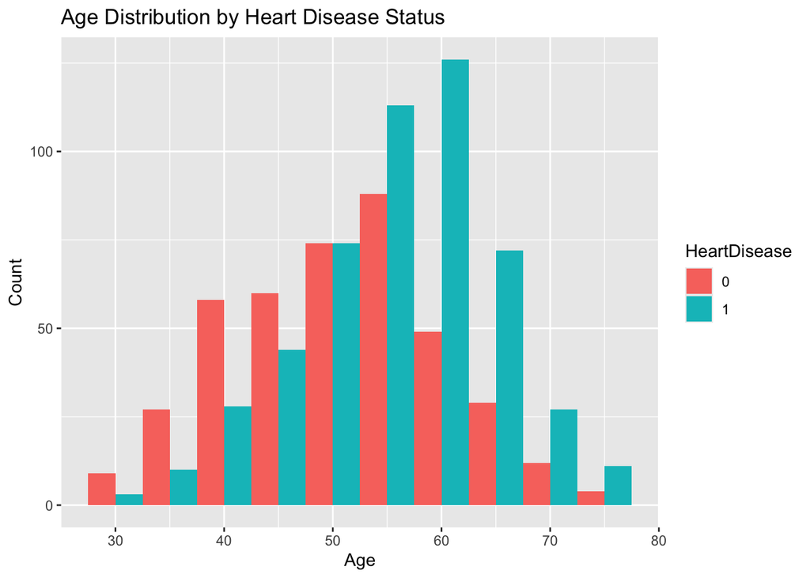

```r
ggplot(heart, aes(x = Age, fill = HeartDisease)) +
  geom_histogram(binwidth = 5, position = "dodge") +
  labs(title = "Age Distribution by Heart Disease Status",
       x = "Age", y = "Count")
```

**Interpretation:**  
Heart disease is most common between **ages 45–65**, consistent with known cardiac risk profiles.

## 5.2 Resting Blood Pressure by Heart Disease

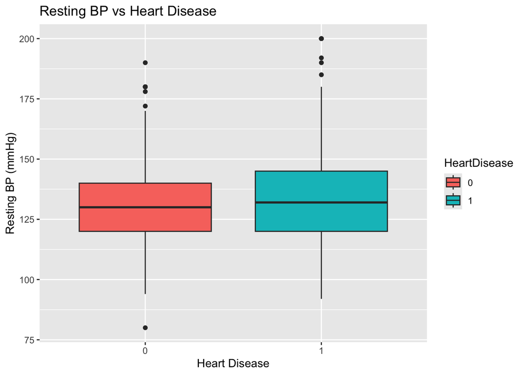

```r
ggplot(heart, aes(x = HeartDisease, y = RestingBP, fill = HeartDisease)) +
  geom_boxplot() +
  labs(title = "Resting BP vs Heart Disease",
       x = "Heart Disease", y = "Resting BP (mmHg)")
```

**Interpretation:**  
RestingBP is **slightly higher** in the heart disease group, though the effect is modest.  
Zero values removed during cleaning produce some NA-related row removals in the plot.

## 5.3 Cholesterol Levels by Heart Disease

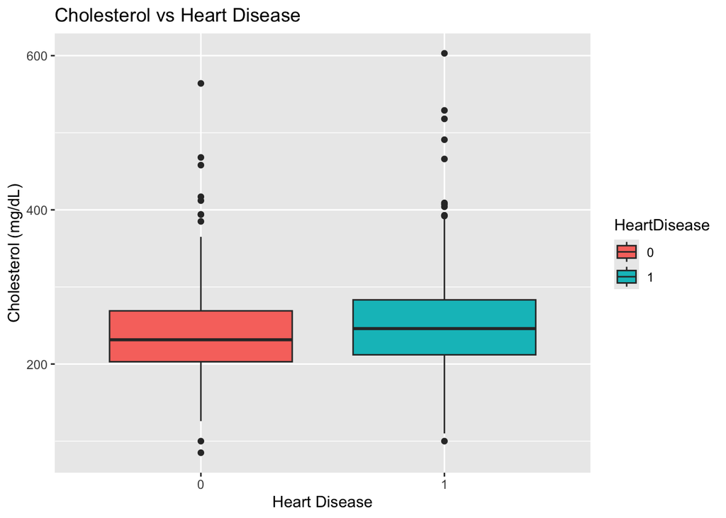

```r
ggplot(heart, aes(x = HeartDisease, y = Cholesterol, fill = HeartDisease)) +
  geom_boxplot() +
  labs(title = "Cholesterol vs Heart Disease",
       x = "Heart Disease", y = "Cholesterol (mg/dL)")
```

## 5.4 Exercise Angina by Heart Disease

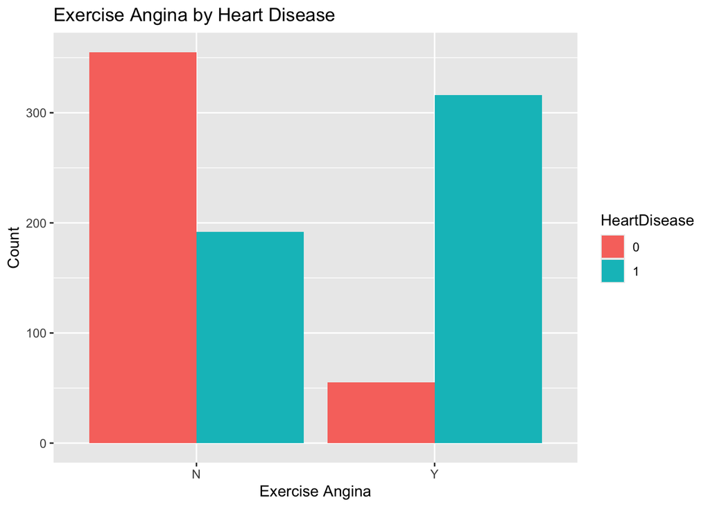

```r
ggplot(heart, aes(x = ExerciseAngina, fill = HeartDisease)) +
  geom_bar(position = "dodge") +
  labs(title = "Exercise Angina by Heart Disease",
       x = "Exercise Angina", y = "Count")
```

**Interpretation:**  
Exercise-induced angina is **much more frequent** in individuals with heart disease, making it a strong indicator.

## 5.5 ST Slope by Heart Disease

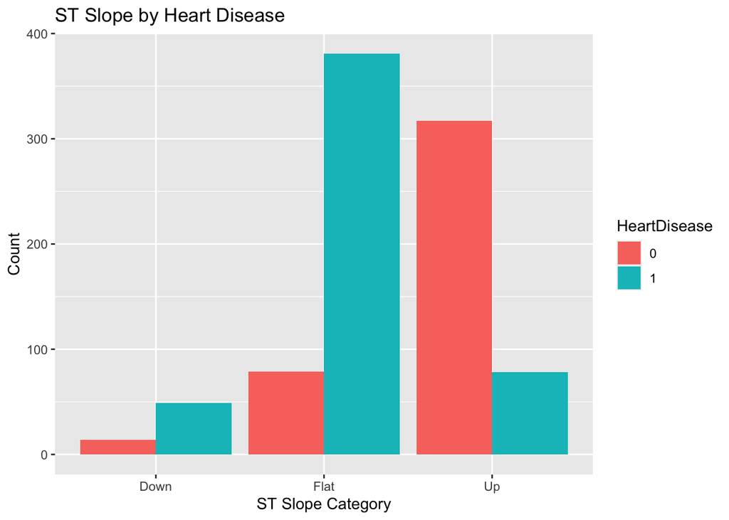

```r
ggplot(heart, aes(x = ST_Slope, fill = HeartDisease)) +
  geom_bar(position = "dodge") +
  labs(title = "ST Slope by Heart Disease",
       x = "ST Slope Category", y = "Count")
```

**Interpretation:**  
A **Flat ST slope** is strongly associated with heart disease, consistent with findings from stress-test analysis.

## 5.6 Chest Pain Type by Heart Disease

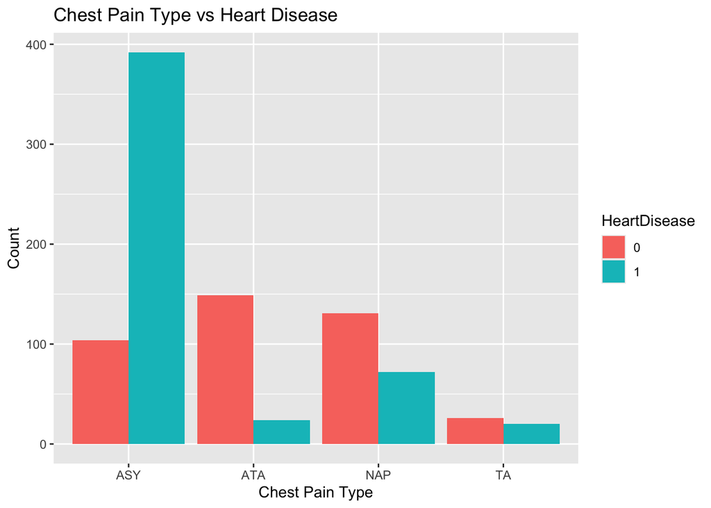

```r
ggplot(heart, aes(x = ChestPainType, fill = HeartDisease)) +
  geom_bar(position = "dodge") +
  labs(title = "Chest Pain Type vs Heart Disease",
       x = "Chest Pain Type", y = "Count")
```

**Interpretation:**  
The **ASY (asymptomatic)** chest pain type is much more common among heart disease patients.

## 5.7 Max Heart Rate vs Age (Scatterplot)

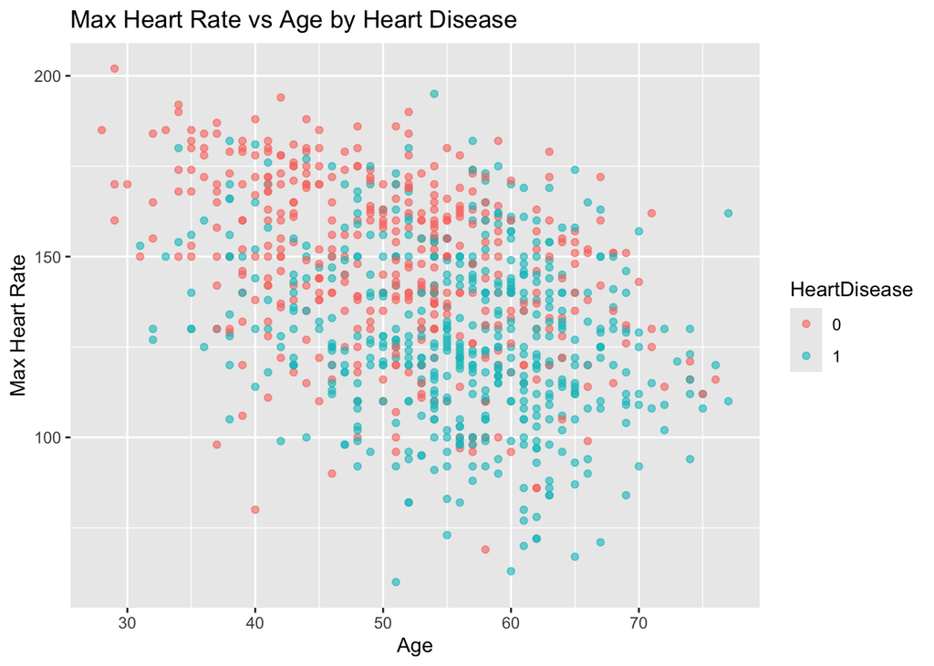

```r
ggplot(heart, aes(x = Age, y = MaxHR, color = HeartDisease)) +
  geom_point(alpha = 0.6) +
  labs(title = "Max Heart Rate vs Age by Heart Disease",
       x = "Age", y = "Max Heart Rate")
```

**Interpretation:**  
MaxHR decreases with age, and heart disease patients generally achieve **lower MaxHR**.

# 6. Export Cleaned Dataset (Required for Deliverable)

```r
write.csv(heart, "/Users/jkwan/Documents/INST447/heart_cleaned.csv", row.names = FALSE)
```

This file must be included with submission.

# Final Interpretation Summary

- Heart disease peaks in ages **45–65**.
- RestingBP shows **slightly higher** levels in heart disease patients.
- Cholesterol differences exist but are **weakly associated** with disease.
- Exercise-induced angina and Flat ST slope are **strong indicators** of heart disease.
- ASY chest pain type appears most frequently in the heart disease group.
- MaxHR decreases with age and tends to be lower in those with heart disease.

These findings set up clear hypotheses for significance testing and regression in Deliverable #3.